# Prueba Técnica -

### Análisis de popularidad de una película y creación de un modelo de predicción

#### 3 de abril de 2021

```python
# Importar módulos
import pandas as pd
import numpy as np
import matplotlib.pyplot as plt
import seaborn as sns
from sklearn.model_selection import train_test_split
from sklearn.metrics import r2_score
from sklearn.metrics import mean_absolute_error
from sklearn.tree import DecisionTreeRegressor
from sklearn.preprocessing import StandardScaler
from datetime import datetime
pd.options.display.float_format = '{:.5f}'.format
```

```python
# Importar datasets
df_movies = pd.read_csv('tmdb_5000_movies.csv')
df_credits = pd.read_csv('tmdb_5000_credits.csv')
```

```python
df_movies.shape
```

```
(4803, 20)
```

```python
df_credits.shape
```

```
(4803, 4)
```

```python
df_movies.head()
```

|  | budget | genres | homepage | id | keywords | original_language | original_title | overview | popularity | production_companies | production_countries | release_date | revenue | runtime | spoken_languages | status | tagline | title | vote_average | vote_count |
| --- | --- | --- | --- | --- | --- | --- | --- | --- | --- | --- | --- | --- | --- | --- | --- | --- | --- | --- | --- | --- |
| 0 | 237000000 | [{"id": 28, "name": "Action"}, {"id": 12, "nam... | http://www.avatarmovie.com/ | 19995 | [{"id": 1463, "name": "culture clash"}, {"id":... | en | Avatar | In the 22nd century, a paraplegic Marine is di... | 150.43758 | [{"name": "Ingenious Film Partners", "id": 289... | [{"iso_3166_1": "US", "name": "United States o... | 2009-12-10 | 2787965087 | 162.00000 | [{"iso_639_1": "en", "name": "English"}, {"iso... | Released | Enter the World of Pandora. | Avatar | 7.20000 | 11800 |
| 1 | 300000000 | [{"id": 12, "name": "Adventure"}, {"id": 14, "... | http://disney.go.com/disneypictures/pirates/ | 285 | [{"id": 270, "name": "ocean"}, {"id": 726, "na... | en | Pirates of the Caribbean: At World's End | Captain Barbossa, long believed to be dead, ha... | 139.08262 | [{"name": "Walt Disney Pictures", "id": 2}, {"... | [{"iso_3166_1": "US", "name": "United States o... | 2007-05-19 | 961000000 | 169.00000 | [{"iso_639_1": "en", "name": "English"}] | Released | At the end of the world, the adventure begins. | Pirates of the Caribbean: At World's End | 6.90000 | 4500 |
| 2 | 245000000 | [{"id": 28, "name": "Action"}, {"id": 12, "nam... | http://www.sonypictures.com/movies/spectre/ | 206647 | [{"id": 470, "name": "spy"}, {"id": 818, "name... | en | Spectre | A cryptic message from Bond’s past sends him o... | 107.37679 | [{"name": "Columbia Pictures", "id": 5}, {"nam... | [{"iso_3166_1": "GB", "name": "United Kingdom"... | 2015-10-26 | 880674609 | 148.00000 | [{"iso_639_1": "fr", "name": "Fran\u00e7ais"},... | Released | A Plan No One Escapes | Spectre | 6.30000 | 4466 |
| 3 | 250000000 | [{"id": 28, "name": "Action"}, {"id": 80, "nam... | http://www.thedarkknightrises.com/ | 49026 | [{"id": 849, "name": "dc comics"}, {"id": 853,... | en | The Dark Knight Rises | Following the death of District Attorney Harve... | 112.31295 | [{"name": "Legendary Pictures", "id": 923}, {"... | [{"iso_3166_1": "US", "name": "United States o... | 2012-07-16 | 1084939099 | 165.00000 | [{"iso_639_1": "en", "name": "English"}] | Released | The Legend Ends | The Dark Knight Rises | 7.60000 | 9106 |
| 4 | 260000000 | [{"id": 28, "name": "Action"}, {"id": 12, "nam... | http://movies.disney.com/john-carter | 49529 | [{"id": 818, "name": "based on novel"}, {"id":... | en | John Carter | John Carter is a war-weary, former military ca... | 43.92699 | [{"name": "Walt Disney Pictures", "id": 2}] | [{"iso_3166_1": "US", "name": "United States o... | 2012-03-07 | 284139100 | 132.00000 | [{"iso_639_1": "en", "name": "English"}] | Released | Lost in our world, found in another. | John Carter | 6.10000 | 2124 |

```python
df_credits.head()
```

|  | movie_id | title | cast | crew |
| --- | --- | --- | --- | --- |
| 0 | 19995 | Avatar | [{"cast_id": 242, "character": "Jake Sully", "... | [{"credit_id": "52fe48009251416c750aca23", "de... |
| 1 | 285 | Pirates of the Caribbean: At World's End | [{"cast_id": 4, "character": "Captain Jack Spa... | [{"credit_id": "52fe4232c3a36847f800b579", "de... |
| 2 | 206647 | Spectre | [{"cast_id": 1, "character": "James Bond", "cr... | [{"credit_id": "54805967c3a36829b5002c41", "de... |
| 3 | 49026 | The Dark Knight Rises | [{"cast_id": 2, "character": "Bruce Wayne / Ba... | [{"credit_id": "52fe4781c3a36847f81398c3", "de... |
| 4 | 49529 | John Carter | [{"cast_id": 5, "character": "John Carter", "c... | [{"credit_id": "52fe479ac3a36847f813eaa3", "de... |

```python
df_movies.columns
```

```
Index(['budget', 'genres', 'homepage', 'id', 'keywords', 'original_language',
       'original_title', 'overview', 'popularity', 'production_companies',
       'production_countries', 'release_date', 'revenue', 'runtime',
       'spoken_languages', 'status', 'tagline', 'title', 'vote_average',
       'vote_count'],
      dtype='object')
```

## Datasets

El dataset "tm'tmdb_5000_movies.csv' tiene 20 features por 4803 observaciones. En su estructura, se observan propiedades de tipo integer, float, strings y estructuras json. El dataset 'tmdb_5000_credits.csv' tiene 4 features y 4803 observaciones

Dado que el objetivo trazado para esta prueba técnica se centra en el análisis de popularidad de una película y creación de un modelo de predicción, toda vez que debe ser ejecutado en un tiempo menor a tres horas, circunscribiremos las dimensiones del modelo a aquellas que no requieren grandes esfuerzos de transformación (especialmente las estrcucturas tipo json)

Descartaremos el dataset de credits ya que sus columnas se refieren al reparto y equipos de dirección y producción. Si bien podríamos relacionar actores, directores y guionistas a la popularidad de la película, debemos descartarlos a fin de enfocarnos en los features que podrían tener mayor relevancia.

## Evaluación y wrangling

```python
# Eliminar features con estructura json
df_movies.drop(columns=['genres',  'keywords', 'production_companies',
       'production_countries', 'spoken_languages'],inplace=True)
```

```python
df_movies.head()
```

|  | budget | homepage | id | original_language | original_title | overview | popularity | release_date | revenue | runtime | status | tagline | title | vote_average | vote_count |
| --- | --- | --- | --- | --- | --- | --- | --- | --- | --- | --- | --- | --- | --- | --- | --- |
| 0 | 237000000 | http://www.avatarmovie.com/ | 19995 | en | Avatar | In the 22nd century, a paraplegic Marine is di... | 150.43758 | 2009-12-10 | 2787965087 | 162.00000 | Released | Enter the World of Pandora. | Avatar | 7.20000 | 11800 |
| 1 | 300000000 | http://disney.go.com/disneypictures/pirates/ | 285 | en | Pirates of the Caribbean: At World's End | Captain Barbossa, long believed to be dead, ha... | 139.08262 | 2007-05-19 | 961000000 | 169.00000 | Released | At the end of the world, the adventure begins. | Pirates of the Caribbean: At World's End | 6.90000 | 4500 |
| 2 | 245000000 | http://www.sonypictures.com/movies/spectre/ | 206647 | en | Spectre | A cryptic message from Bond’s past sends him o... | 107.37679 | 2015-10-26 | 880674609 | 148.00000 | Released | A Plan No One Escapes | Spectre | 6.30000 | 4466 |
| 3 | 250000000 | http://www.thedarkknightrises.com/ | 49026 | en | The Dark Knight Rises | Following the death of District Attorney Harve... | 112.31295 | 2012-07-16 | 1084939099 | 165.00000 | Released | The Legend Ends | The Dark Knight Rises | 7.60000 | 9106 |
| 4 | 260000000 | http://movies.disney.com/john-carter | 49529 | en | John Carter | John Carter is a war-weary, former military ca... | 43.92699 | 2012-03-07 | 284139100 | 132.00000 | Released | Lost in our world, found in another. | John Carter | 6.10000 | 2124 |

```python
# Eliminaremos la homepage, id, overview, tagline
df_movies.drop(columns=['homepage','id','overview','tagline'],inplace=True)
```

```python
df_movies
```

|  | budget | original_language | original_title | popularity | release_date | revenue | runtime | status | title | vote_average | vote_count |
| --- | --- | --- | --- | --- | --- | --- | --- | --- | --- | --- | --- |
| 0 | 237000000 | en | Avatar | 150.43758 | 2009-12-10 | 2787965087 | 162.00000 | Released | Avatar | 7.20000 | 11800 |
| 1 | 300000000 | en | Pirates of the Caribbean: At World's End | 139.08262 | 2007-05-19 | 961000000 | 169.00000 | Released | Pirates of the Caribbean: At World's End | 6.90000 | 4500 |
| 2 | 245000000 | en | Spectre | 107.37679 | 2015-10-26 | 880674609 | 148.00000 | Released | Spectre | 6.30000 | 4466 |
| 3 | 250000000 | en | The Dark Knight Rises | 112.31295 | 2012-07-16 | 1084939099 | 165.00000 | Released | The Dark Knight Rises | 7.60000 | 9106 |
| 4 | 260000000 | en | John Carter | 43.92699 | 2012-03-07 | 284139100 | 132.00000 | Released | John Carter | 6.10000 | 2124 |
| ... | ... | ... | ... | ... | ... | ... | ... | ... | ... | ... | ... |
| 4798 | 220000 | es | El Mariachi | 14.26979 | 1992-09-04 | 2040920 | 81.00000 | Released | El Mariachi | 6.60000 | 238 |
| 4799 | 9000 | en | Newlyweds | 0.64255 | 2011-12-26 | 0 | 85.00000 | Released | Newlyweds | 5.90000 | 5 |
| 4800 | 0 | en | Signed, Sealed, Delivered | 1.44448 | 2013-10-13 | 0 | 120.00000 | Released | Signed, Sealed, Delivered | 7.00000 | 6 |
| 4801 | 0 | en | Shanghai Calling | 0.85701 | 2012-05-03 | 0 | 98.00000 | Released | Shanghai Calling | 5.70000 | 7 |
| 4802 | 0 | en | My Date with Drew | 1.92988 | 2005-08-05 | 0 | 90.00000 | Released | My Date with Drew | 6.30000 | 16 |

4803 rows × 11 columns

```python
# Análisis de duplicados
df_movies[df_movies.duplicated() == True].count()
```

```
budget               0
original_language    0
original_title       0
popularity           0
release_date         0
revenue              0
runtime              0
status               0
title                0
vote_average         0
vote_count           0
dtype: int64
```

```python
df_movies.isna().sum()
```

```
budget               0
original_language    0
original_title       0
popularity           0
release_date         1
revenue              0
runtime              2
status               0
title                0
vote_average         0
vote_count           0
dtype: int64
```

```python
df_movies.dropna(inplace=True)
```

```python
# Análisis de tipos de datos
df_movies.info()
```

```
<class 'pandas.core.frame.DataFrame'>
Int64Index: 4800 entries, 0 to 4802
Data columns (total 11 columns):
 #   Column             Non-Null Count  Dtype
---  ------             --------------  -----
 0   budget             4800 non-null   int64
 1   original_language  4800 non-null   object
 2   original_title     4800 non-null   object
 3   popularity         4800 non-null   float64
 4   release_date       4800 non-null   object
 5   revenue            4800 non-null   int64
 6   runtime            4800 non-null   float64
 7   status             4800 non-null   object
 8   title              4800 non-null   object
 9   vote_average       4800 non-null   float64
 10  vote_count         4800 non-null   int64
dtypes: float64(3), int64(3), object(5)
memory usage: 450.0+ KB
```

El dataset no tiene nulls

```python
# Release_date a datetime
# Formato originalYYYY-mm-dd
df_movies.release_date = pd.to_datetime(df_movies.release_date, format='%Y-%m-%d')
# Controlar
df_movies.release_date.head()
```

```
0   2009-12-10
1   2007-05-19
2   2015-10-26
3   2012-07-16
4   2012-03-07
Name: release_date, dtype: datetime64[ns]
```

```python
# Chequear distribución variables
```

```python
df_movies.describe()
```

|  | budget | popularity | revenue | runtime | vote_average | vote_count |
| --- | --- | --- | --- | --- | --- | --- |
| count | 4800.00000 | 4800.00000 | 4800.00000 | 4800.00000 | 4800.00000 | 4800.00000 |
| mean | 29060068.02479 | 21.50557 | 82312051.55083 | 106.89812 | 6.09446 | 690.64688 |
| std | 40730294.63879 | 31.82216 | 162895004.59102 | 22.56159 | 1.18837 | 1234.85245 |
| min | 0.00000 | 0.00037 | 0.00000 | 0.00000 | 0.00000 | 0.00000 |
| 25% | 800000.00000 | 4.68221 | 0.00000 | 94.00000 | 5.60000 | 54.00000 |
| 50% | 15000000.00000 | 12.92890 | 19181992.00000 | 103.00000 | 6.20000 | 236.00000 |
| 75% | 40000000.00000 | 28.35063 | 92938861.00000 | 118.00000 | 6.80000 | 737.25000 |
| max | 380000000.00000 | 875.58131 | 2787965087.00000 | 338.00000 | 10.00000 | 13752.00000 |

- Existencia de features con valor cero
- No se observan valores negativos
- Altos valores de desvíos
- Presencia de outliers (max)

Para maximizar el tiempo invertido, se graficará directamente con pandas

## Análsis univariable

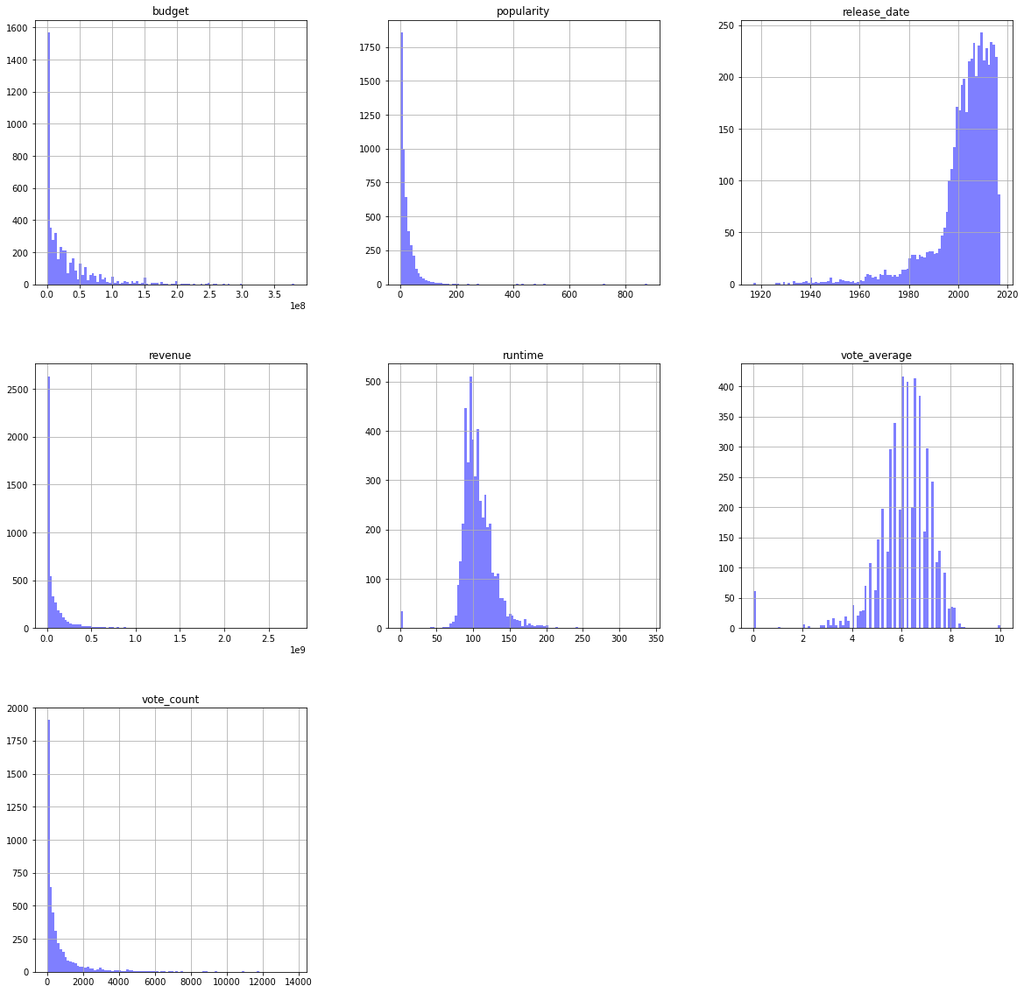

```python
df_movies.hist(color='b', alpha=0.5, bins=100, figsize=(20,20));
```

```python
# Eliminaremos las películas con popularidad 0, ya que es nuestra variable dependiente
df_movies[df_movies.popularity==0]
```

|  | budget | original_language | original_title | popularity | release_date | revenue | runtime | status | title | vote_average | vote_count |
| --- | --- | --- | --- | --- | --- | --- | --- | --- | --- | --- | --- |

```python
df_movies = df_movies[df_movies.popularity!=0]
```

```python
df_movies[df_movies.budget==0].count()
```

```
budget               1036
original_language    1036
original_title       1036
popularity           1036
release_date         1036
revenue              1036
runtime              1036
status               1036
title                1036
vote_average         1036
vote_count           1036
dtype: int64
```

```python
# Porcentaje de observaciones con budget en 0
df_movies[df_movies.budget==0].budget.count() / len(df_movies)
```

```
0.21583333333333332
```

```python
df_movies[df_movies.revenue==0].count()
```

```
budget               1424
original_language    1424
original_title       1424
popularity           1424
release_date         1424
revenue              1424
runtime              1424
status               1424
title                1424
vote_average         1424
vote_count           1424
dtype: int64
```

```python
# Porcentaje de observaciones con revenue en 0
df_movies[df_movies.revenue==0].revenue.count() / len(df_movies)
```

```
0.2966666666666667
```

```python
# Feature engineering del año
df_movies['year'] = pd.DatetimeIndex(df_movies.release_date).year
```

```python
df_movies
```

|  | budget | original_language | original_title | popularity | release_date | revenue | runtime | status | title | vote_average | vote_count | year |
| --- | --- | --- | --- | --- | --- | --- | --- | --- | --- | --- | --- | --- |
| 0 | 237000000 | en | Avatar | 150.43758 | 2009-12-10 | 2787965087 | 162.00000 | Released | Avatar | 7.20000 | 11800 | 2009 |
| 1 | 300000000 | en | Pirates of the Caribbean: At World's End | 139.08262 | 2007-05-19 | 961000000 | 169.00000 | Released | Pirates of the Caribbean: At World's End | 6.90000 | 4500 | 2007 |
| 2 | 245000000 | en | Spectre | 107.37679 | 2015-10-26 | 880674609 | 148.00000 | Released | Spectre | 6.30000 | 4466 | 2015 |
| 3 | 250000000 | en | The Dark Knight Rises | 112.31295 | 2012-07-16 | 1084939099 | 165.00000 | Released | The Dark Knight Rises | 7.60000 | 9106 | 2012 |
| 4 | 260000000 | en | John Carter | 43.92699 | 2012-03-07 | 284139100 | 132.00000 | Released | John Carter | 6.10000 | 2124 | 2012 |
| ... | ... | ... | ... | ... | ... | ... | ... | ... | ... | ... | ... | ... |
| 4798 | 220000 | es | El Mariachi | 14.26979 | 1992-09-04 | 2040920 | 81.00000 | Released | El Mariachi | 6.60000 | 238 | 1992 |
| 4799 | 9000 | en | Newlyweds | 0.64255 | 2011-12-26 | 0 | 85.00000 | Released | Newlyweds | 5.90000 | 5 | 2011 |
| 4800 | 0 | en | Signed, Sealed, Delivered | 1.44448 | 2013-10-13 | 0 | 120.00000 | Released | Signed, Sealed, Delivered | 7.00000 | 6 | 2013 |
| 4801 | 0 | en | Shanghai Calling | 0.85701 | 2012-05-03 | 0 | 98.00000 | Released | Shanghai Calling | 5.70000 | 7 | 2012 |
| 4802 | 0 | en | My Date with Drew | 1.92988 | 2005-08-05 | 0 | 90.00000 | Released | My Date with Drew | 6.30000 | 16 | 2005 |

4800 rows × 12 columns

```python
df_movies[df_movies.vote_count==0].count()
```

```
budget               60
original_language    60
original_title       60
popularity           60
release_date         60
revenue              60
runtime              60
status               60
title                60
vote_average         60
vote_count           60
year                 60
dtype: int64
```

```python
df_movies[df_movies.vote_average==0].count()
```

```
budget               61
original_language    61
original_title       61
popularity           61
release_date         61
revenue              61
runtime              61
status               61
title                61
vote_average         61
vote_count           61
year                 61
dtype: int64
```

```python
df_movies[df_movies.runtime==0].count()
```

```
budget               34
original_language    34
original_title       34
popularity           34
release_date         34
revenue              34
runtime              34
status               34
title                34
vote_average         34
vote_count           34
year                 34
dtype: int64
```

```python
df_movies.status.value_counts()
```

```
Released           4792
Rumored               5
Post Production       3
Name: status, dtype: int64
```

```python
df_movies.original_language.value_counts()
```

```
en    4503
fr      70
es      32
de      27
zh      27
hi      19
ja      16
it      13
cn      12
ru      11
ko      11
pt       9
da       7
sv       5
nl       4
fa       4
th       3
he       3
id       2
ro       2
ta       2
ar       2
cs       2
sl       1
hu       1
el       1
is       1
ky       1
no       1
nb       1
pl       1
ps       1
te       1
vi       1
xx       1
af       1
tr       1
Name: original_language, dtype: int64
```